# Chapter 7 Basic Plotting

# 7.1 Using `plot` with Coordinate Vectors

Basic plotting with `plot()` and two vectors

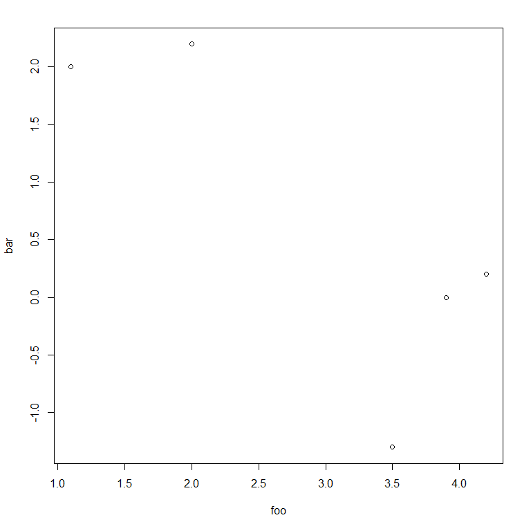

```r
foo <- c(1.1, 2, 3.5, 3.9, 4.2)
bar <- c(2, 2.2, -1.3, 0, 0.2)
plot(foo, bar)
```

Can just use a matrix with `plot()`

```r
baz <- cbind(foo, bar)
baz
```

```
     foo  bar
[1,] 1.1  2.0
[2,] 2.0  2.2
[3,] 3.5 -1.3
[4,] 3.9  0.0
[5,] 4.2  0.2
```

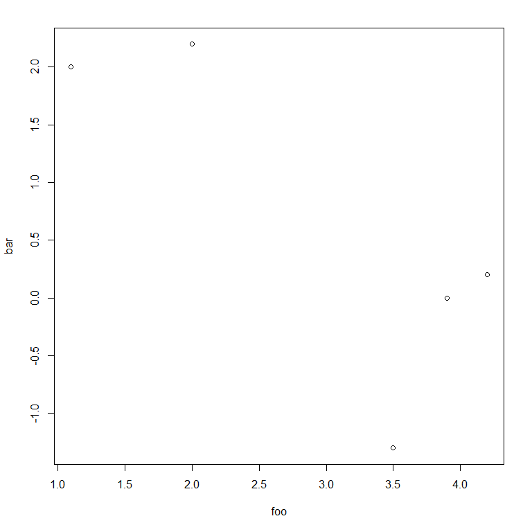

```r
plot(baz)
```

# 7.2 Graphical Parameters

Many keywords for `plot()` :

| Keyword | Effect |
| --- | --- |
| `type` | How points should be plotted |
| `main`, `xlab`, `ylab` | Change title, x, and y labels |
| `col` | Change colours |
| `pch` | Change point character |
| `cex` | Change character size |
| `lty` | Change line type |
| `lwd` | Change line width |
| `xlim`, `ylim` | Change x and y plotting limits |

## 7.2.1 Automatic Plot Types

Defaults to individual points.

Change to line plot: `type="l"`

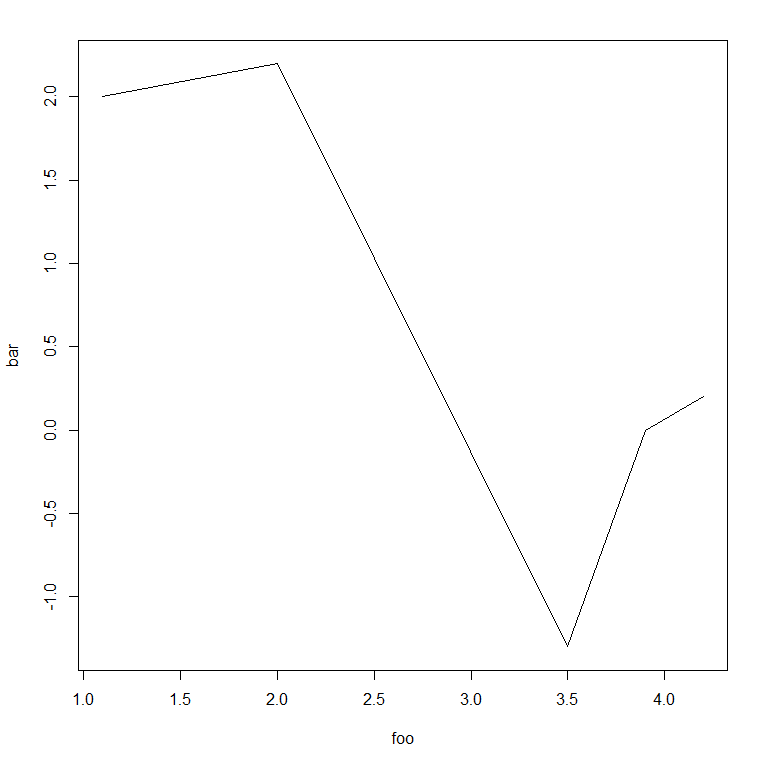

```r
plot(foo, bar, type="l")
```

Change to line and dots: `type="b"`

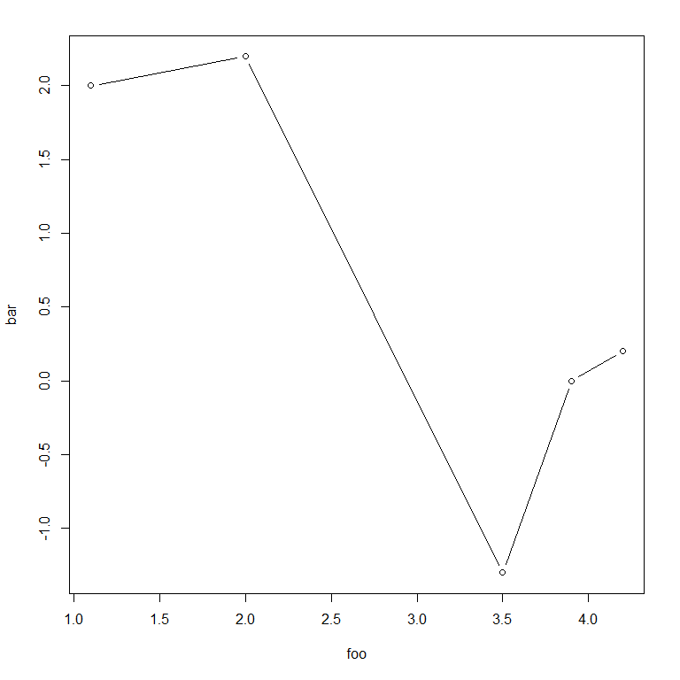

```r
plot(foo, bar, type="b")
```

## 7.2.2 Title and Axis Labels

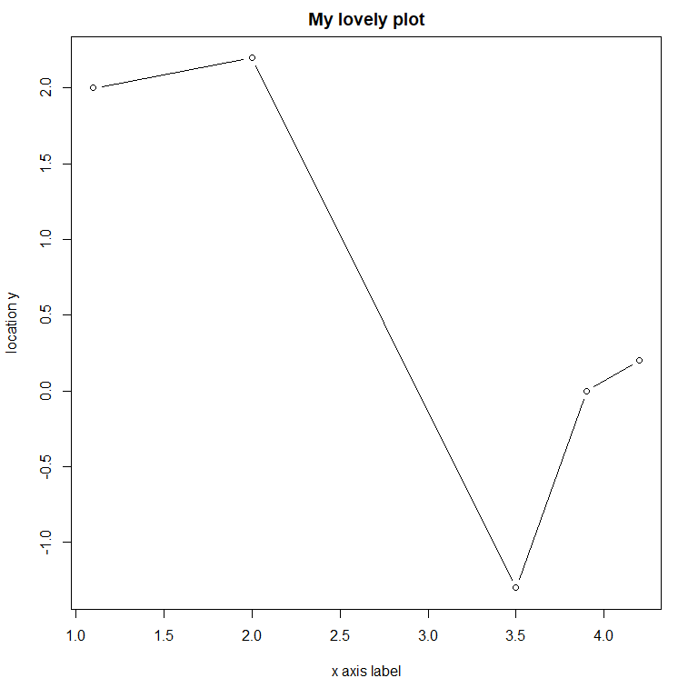

```r
plot(
    foo, bar,
    type="b",
    main="My lovely plot",
    xlab="x axis label",
    ylab="location y"
    )
```

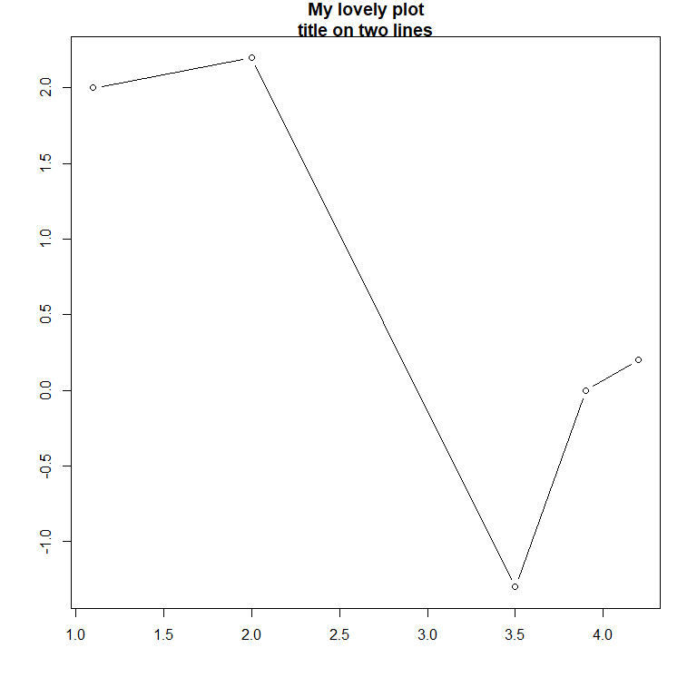

```r
plot(
    foo, bar,
    type="b",
    main="My lovely plot\ntitle on two lines",
    xlab="",
    ylab=""
    )
```

## 7.2.3 Colour

Can change colour with `col=` either an integer or a colour string

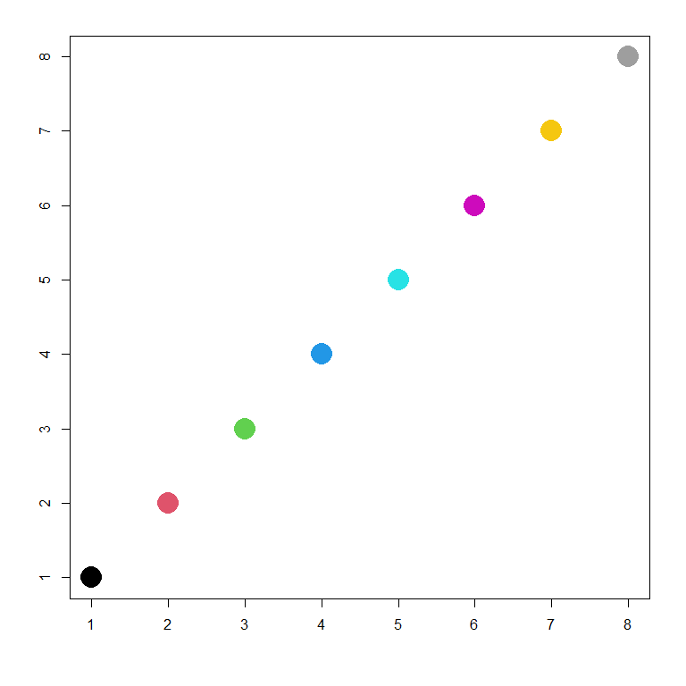

```r
plot(
    1:8, 1:8,
    col=1:8,
    cex=5,
    pch=20,
    xlab="",
    ylab=""
    )
```

## 7.2.4 Line and Point Appearances

Can change point character and line types with `pch=` and `lty=`

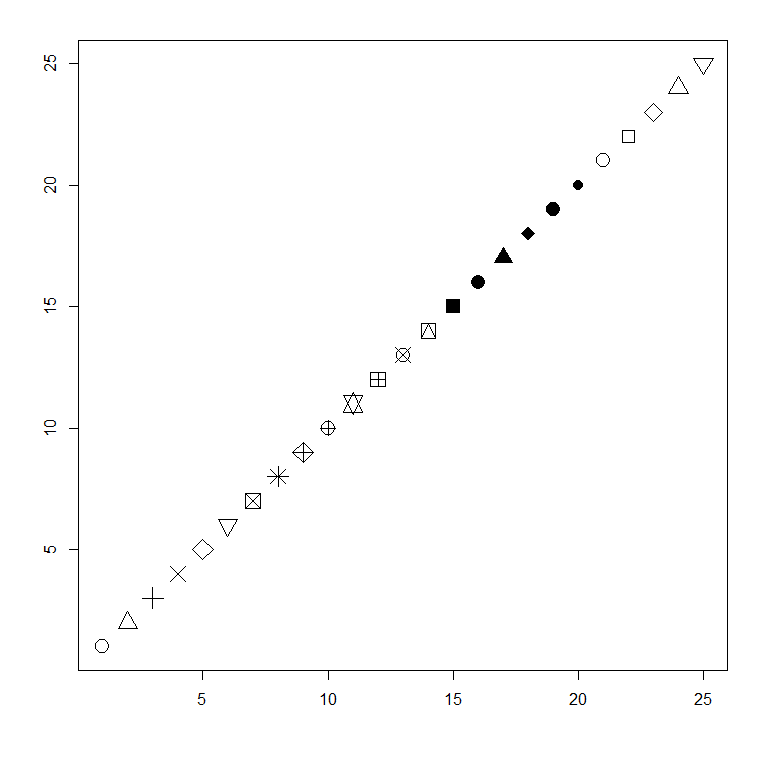

```r
plot(
    1:25, 1:25,
    pch=1:25,
    cex=2,
    xlab="",
    ylab=""
    )
```

```r
plot(c(1, 1), c(0, 1),
     lty=1, type="l", xlim=c(1, 6), xlab="", ylab="")
lines(c(2, 2), c(0, 1), lty=2, type="l")
```

```r
lines(c(3, 3), c(0, 1), lty=3, type="l")
lines(c(4, 4), c(0, 1), lty=4, type="l")
```

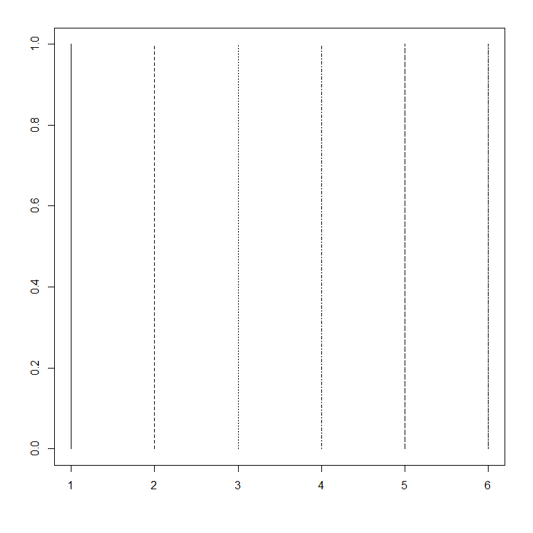

```r
lines(c(5, 5), c(0, 1), lty=5, type="l")
lines(c(6, 6), c(0, 1), lty=6, type="l")
```

## 7.2.5 Plotting Region Limits

Change the plotting region with `xlim=` and `ylim=`

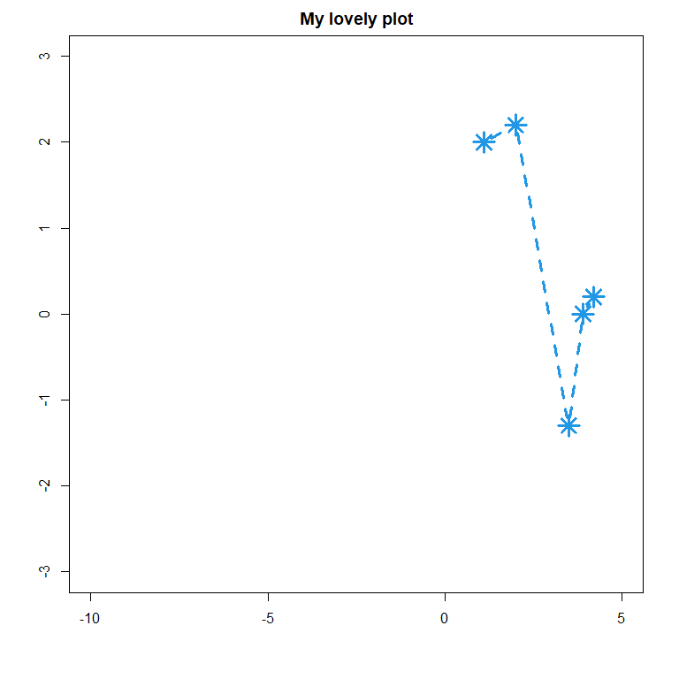

```r
plot(
    foo, bar,
    type='b',
    main="My lovely plot",
    xlab="",
    ylab="",
    col=4,
    pch=8,
    lty=2,
    cex=2.3,
    lwd=3.3,
    xlim=c(-10, 5),
    ylim=c(-3, 3)
    )
```

# 7.3 Adding Points, Lines, and Text to an Existing Plot

Can add to existing plots using:

| Function | Description |
| --- | --- |
| `points()` | Adds points |
| `lines()`, `abline()`, `segments()` | Adds lines |
| `text()` | Writes text |
| `arrows()` | Adds arrows |
| `legend()` | Adds a legend |

Used in the same manor as `plot()`

```r
x <- 1:20
y <- c(
        -1.49, 3.37, 2.59, -2.78, -3.94,
        -0.92, 6.43, 8.51, 3.41, -8.23,
        -12.01, -6.58, 2.87, 14.12, 9.63,
        -4.58, -14.78, -11.67, 1.17, 15.62
        )
```

```r
plot(x, y, type="n", main="")
abline(h=c(-5, 5), col="red", lty=2, lwd=2)
```

```r
segments(
        x0=c(5, 15), y0=c(-5, -5),
        x1=c(5, 15), y1=c(5, 5),
        col="red",
        lty=3,
        lwd=2
        )
points(x[y >= 5], y[y >= 5], pch=4, col="darkmagenta", cex=2)
```

```r
points(x[y <= 5], y[y <= 5], pch=3, col="darkgreen", cex=2)
points(
        x[(x >= 5 & x <= 15) & (y > -5 & y < 5)],
        y[(x >= 5 & x <= 15) & (y > -5 & y < 5)],
        pch=19,
        col="blue"
        )
```

```r
points(
        x[(x < 5 | x > 15) & (y > -5 & y < 5)],
        y[(x < 5 | x > 15) & (y > -5 & y < 5)]
        )
lines(x, y, lty=4)
```

```r
arrows(x0=8, y0=14, x1=11, y1=2.5)
text(x=8, y=15, labels="sweet spot")
```

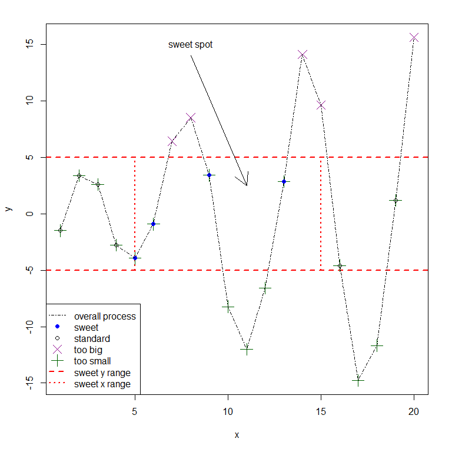

```r
legend(
        "bottomleft",
        legend=c(
                "overall process",
                "sweet",
                "standard",
                "too big",
                "too small",
                "sweet y range",
                "sweet x range"
                ),
        pch=c(NA, 19, 1, 4, 3, NA, NA),
        lty=c(4, NA, NA, NA, NA, 2, 3),
        col=c(
            "black",
            "blue",
            "black",
            "darkmagenta",
            "darkgreen",
            "red",
            "red"
            ),
        lwd=c(1, NA, NA, NA, NA, 2, 2),
        pt.cex=c(NA, 1, 1, 2, 2, NA, NA)
        )
```

## 7.1 Exercises

### (a) Recreate the following:

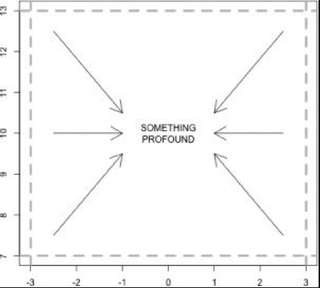

```r
x <- -3:3
y <- 7:13

plot(x, y, type='n', main='', xlab='', ylab='')
abline(h=c(7, 13), v=c(-3, 3), col='red', lty=5, lwd=1.5)
```

```r
arrows(x0=-2.5, y0=12.5, x1=-1, y1=10.5)
arrows(x0=2.5, y0=12.5, x1=1, y1=10.5)
```

```r
arrows(x0=-2.5, y0=10, x1=-1, y1=10)
arrows(x0=2.5, y0=10, x1=1, y1=10)
```

```r
arrows(x0=-2.5, y0=7.5, x1=-1, y1=9.5)
arrows(x0=2.5, y0=7.5, x1=1, y1=9.5)
```

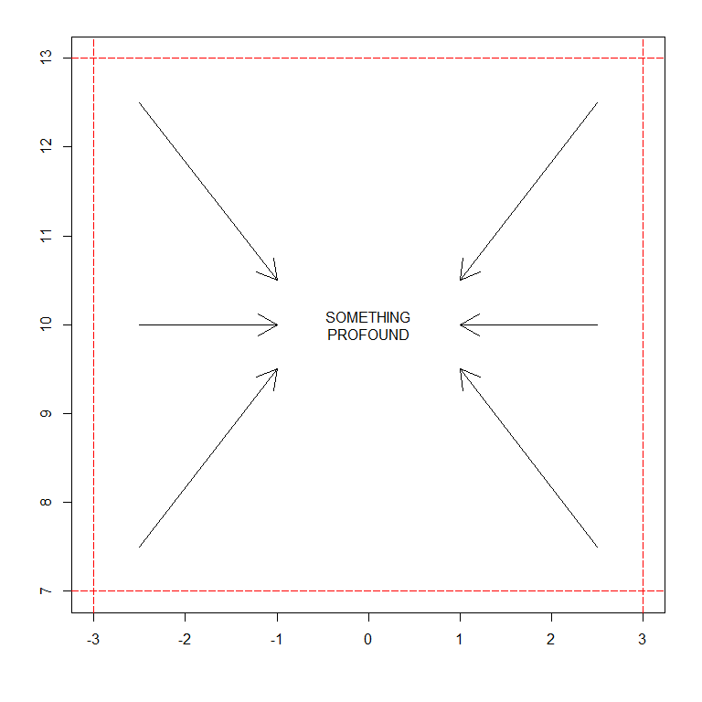

```r
text(x=0, y=10, labels='SOMETHING\nPROFOUND')
```

### (b) Using the following data: create a plot of weight Vs height. Use different point characters or colours to distinguish males and females, provide a legend, title, and axis labels.

| Weight (kg) | Height (cm) | Sex |
| --- | --- | --- |
| 55 | 161 | female |
| 85 | 185 | male |
| 75 | 174 | male |
| 42 | 154 | female |
| 93 | 188 | male |
| 63 | 178 | male |
| 58 | 170 | female |
| 75 | 167 | male |
| 89 | 181 | male |
| 67 | 178 | female |

```r
Weight <- c(55, 85, 75, 42, 93, 63, 58, 75, 89, 67)
Height <- c(161, 185, 174, 154, 188, 178, 170, 167, 181, 178)
Sex <- factor(c('female', 'male', 'male', 'female', 'male', 'male', 'female',
                'male', 'male', 'female'))
B <- data.frame(Weight, Height, Sex)

plot(B$Weight, B$Height, type='n', xlab='Weight / kg', ylab='Height / cm',
     main='Plot of Weight (kg) vs Height (cm)')
points(B$Weight[B$Sex == 'male'], B$Height[B$Sex == 'male'], pch=2, col='blue',
       cex=2)
```

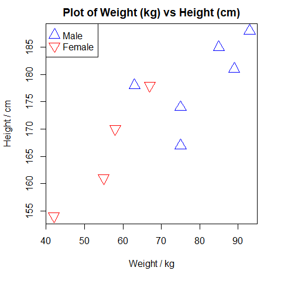

```r
points(B$Weight[B$Sex == 'female'], B$Height[B$Sex == 'female'], pch=6,
       col='red', cex=2)
legend(
    'topleft',
    legend=c('Male', 'Female'),
    pch=c(2, 6),
    col=c('blue', 'red'),
    pt.cex=c(2, 2)
)
```

# 7.4 The `ggplot2` Package

More powerful plotting library than `base-r`

## 7.4.1 A Quick Plot with `qplot`

Need to load with `library()`

```r
library("ggplot2")
```

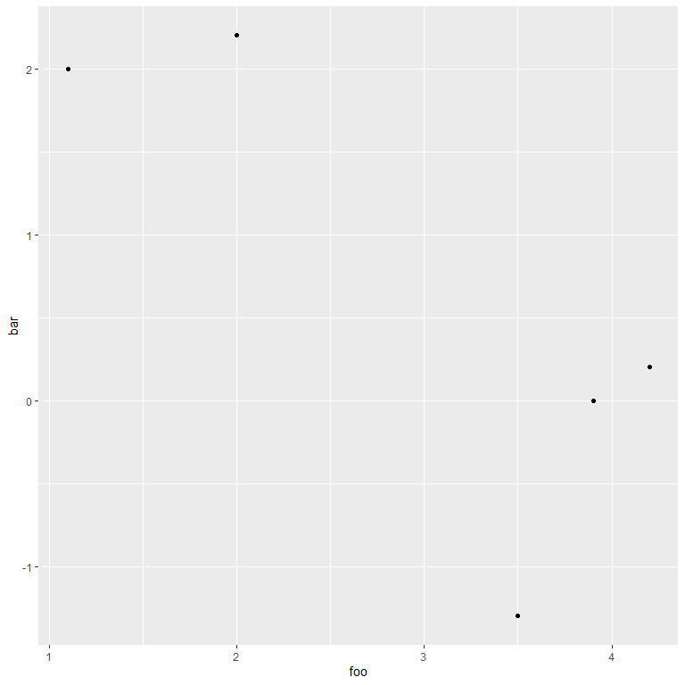

```r
foo <- c(1.1, 2, 3.5, 3.9, 4.2)
bar <- c(2, 2.2, -1.3, 0, 0.2)

qplot(foo, bar)
```

Very similar to base-r `plot()`

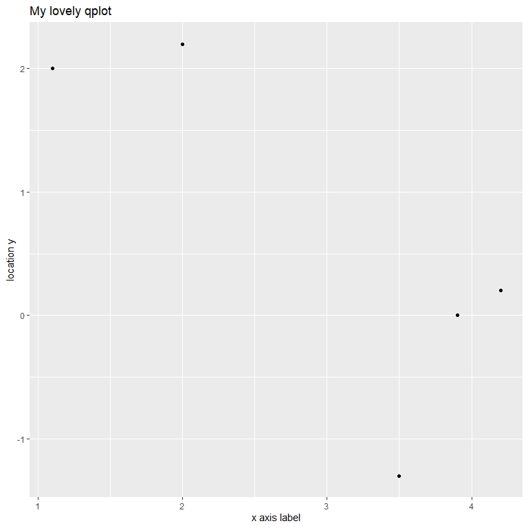

```r
qplot(
    foo, bar,
    main="My lovely qplot",
    xlab="x axis label",
    ylab="location y"
    )
```

`qplot()` can be saved as an object and modified

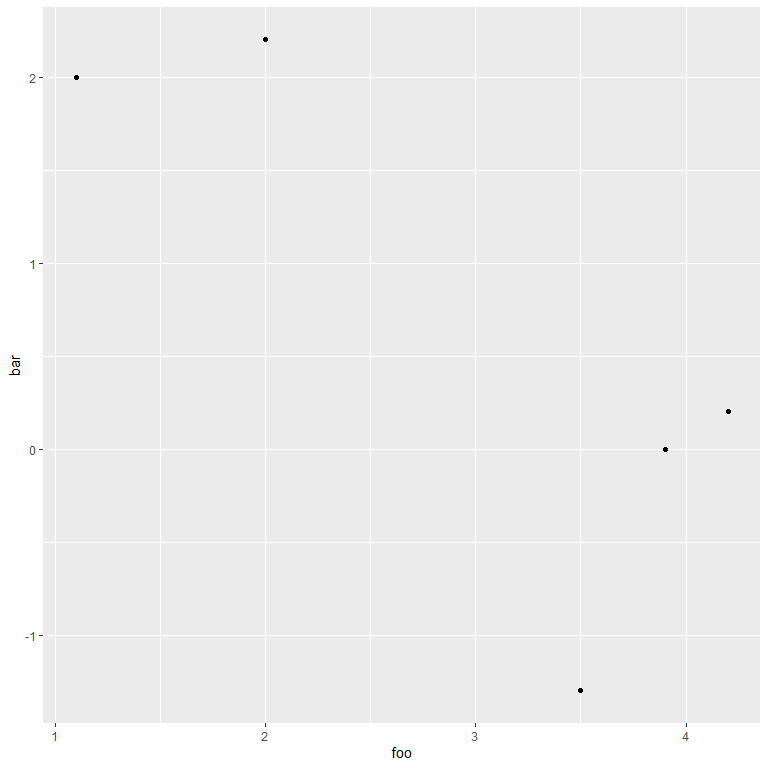

```r
qux <- qplot(foo, bar)
qux
```

## 7.4.2 Setting Appearance Constants with Geoms

Extra setting are modified with `geom_*()` function objects

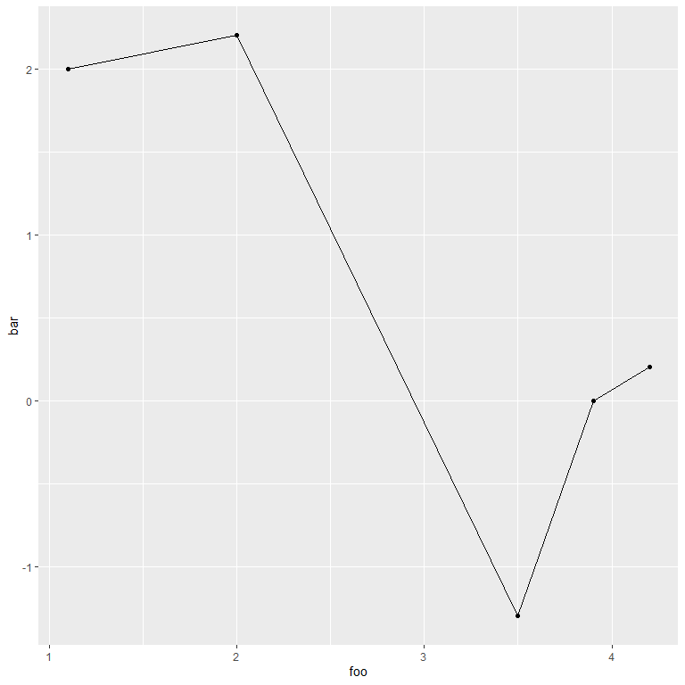

```r
qplot(foo, bar, geom="blank") + geom_point() + geom_line()
```

Each geom object has its own set of keyword argument modifiers

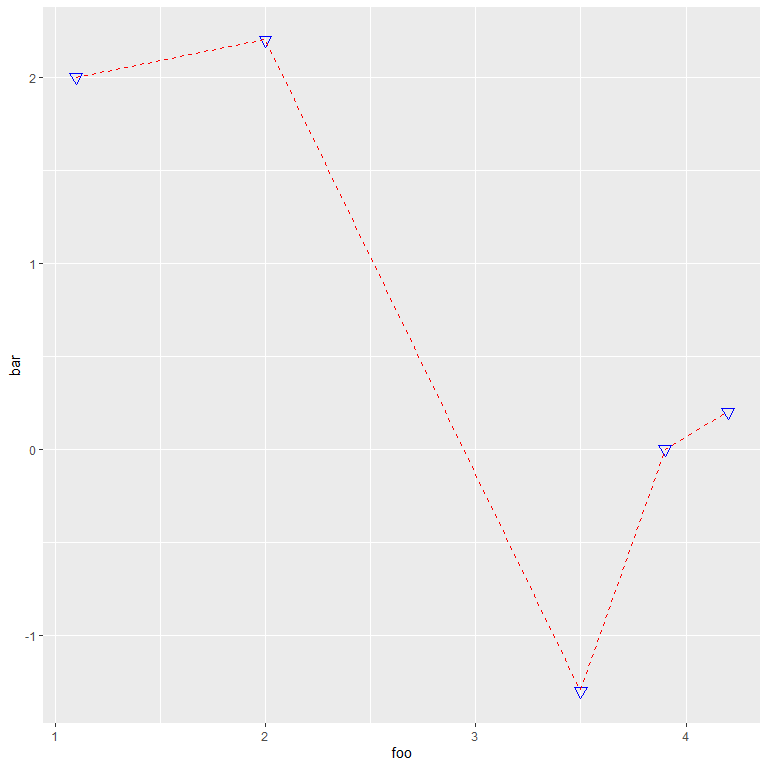

```r
(
qplot(foo, bar, geom="blank") +
geom_point(size=3, shape=6, color="blue") +
geom_line(color="red", linetype=2)
)
```

Can easily overwrite geoms

```r
my_qplot <- (
            qplot(foo, bar, geom="blank") +
            geom_line(color="red", linetype=2)
            )
```

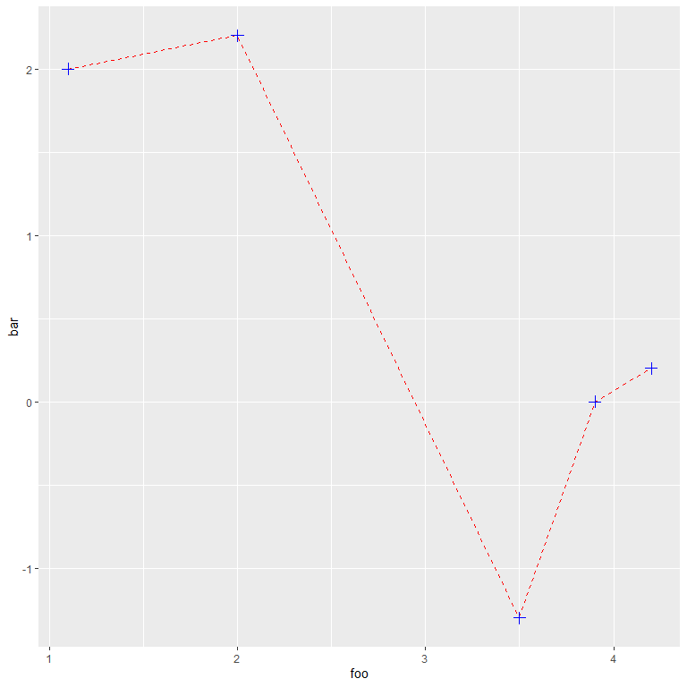

```r
my_qplot + geom_point(size=3, shape=3, color="blue")
```

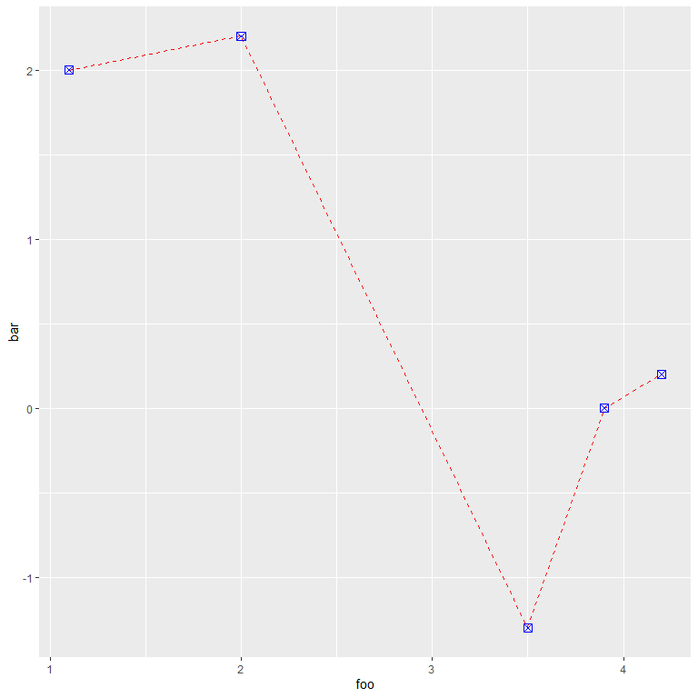

```r
my_qplot + geom_point(size=3, shape=7, color="blue")
```

## 7.4.3 Aesthetic Mapping with Geoms

Can easily set colours and styles with categorical data

```r
x <- 1:20
y <- c(
        -1.49, 3.37, 2.59, -2.78, -3.94,
        -0.92, 6.43, 8.51, 3.41, -8.23,
        -12.01, -6.58, 2.87, 14.12, 9.63,
        -4.58, -14.78, -11.67, 1.17, 15.62
        )
```

```r
ptype <- rep(NA, length(x=x))
ptype[y >= 5] <- "too_big"
ptype[y <= -5] <- "too_small"
ptype[(x >= 5 & x <= 15) & (y > -5 & y < 5)] <- "sweet"
ptype[(x < 5 | x > 15) & (y > -5 & y < 5)] <- "standard"
ptype <- factor(x=ptype)
ptype
```

```
 [1] standard  standard  standard  standard  sweet     sweet     too_big   too_big
 [9] sweet     too_small too_small too_small sweet     too_big   too_big   standard
[17] too_small too_small standard  too_big
Levels: standard sweet too_big too_small
```

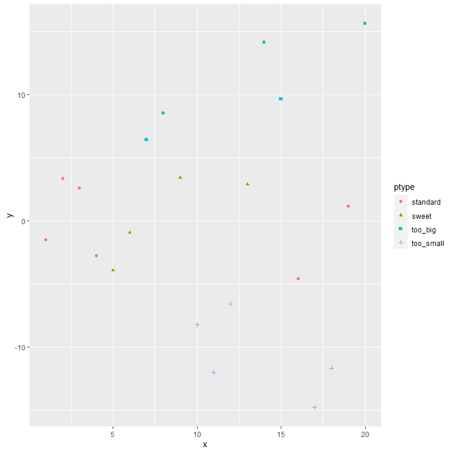

```r
qplot(x, y, color=ptype, shape=ptype)
```

Need to use `aes()` to change aesthetic mapping

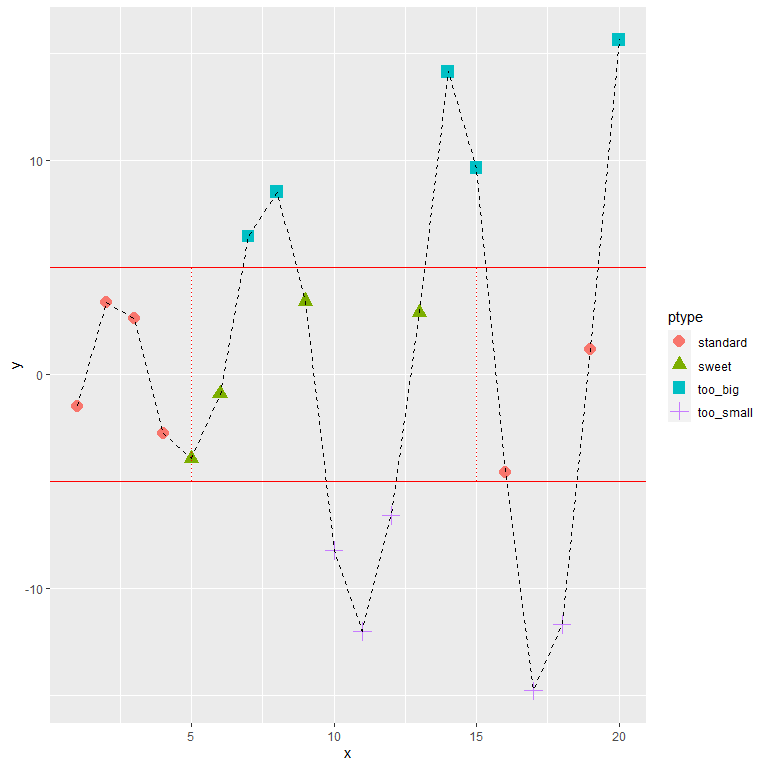

```r
(
    qplot(x, y, color=ptype, shape=ptype)
    + geom_point(size=4)
    + geom_line(mapping=aes(group=1), color="black", lty=2)
    + geom_hline(mapping=aes(yintercept=c(-5, 5)), color="red")
    + geom_segment(
                mapping=aes(x=5, y=-5, xend=5, yend=5),
                color="red",
                lty=3
                )
    + geom_segment(
                mapping=aes(x=15, y=-5, xend=15, yend=5),
                color="red",
                lty=3
                )
)
```

## 7.2 Exercises

### Using the data from Exercise 7.1 (b), redo the plot using ggplot2

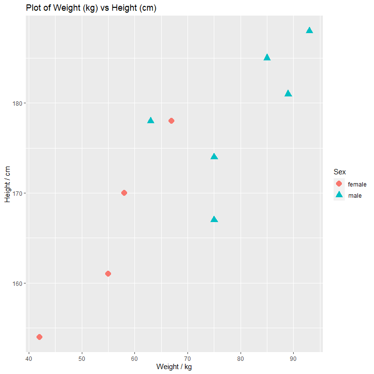

```r
Weight <- c(55, 85, 75, 42, 93, 63, 58, 75, 89, 67)
Height <- c(161, 185, 174, 154, 188, 178, 170, 167, 181, 178)
Sex <- factor(
            c('female', 'male', 'male', 'female', 'male',
              'male', 'female', 'male', 'male', 'female')
            )
A <- data.frame(Weight, Height, Sex)

p <- (
        qplot(
                A$Weight, A$Height,
                color=A$Sex,
                shape=A$Sex,
                xlab='Weight / kg',
                ylab='Height / cm',
                main='Plot of Weight (kg) vs Height (cm)'
            )
    + geom_point(size=4) + labs(color='Sex', shape='Sex')
    )
p
```